# Pràctica pre-examen

Afecta tenir un estil de vida saludable en el nostre rendiment acadèmic?

Autor/a

Miquel Àngel Aguiló Gonzalez

Publicat

13 de novembre de 2024

Enllaç: https://github.com/mikiaguilo/Entrega_preexamen

En aquest treball ens dedicarem a estudiar com afecta dur una vida activa i saludable als estudis, sota la hipòtesi de que dur una vida activa i saludable implica millor rendiment acadèmic. Per això mirarem les **hores d’activitat física** que fa un alumne a la setmana, les **hores de son** de mitjana al dia, **mitjana expedient,** i el **nombre de menjades “trampa”** que fa un alume per setmana. Per altre banda, es demanarà el **Nivell d’energia percebut**: Classificat com “baix”, “mitjà”, “alt” i “molt alt”, la **percepció del nivell d’estrès**: Classificat com “baix”, “mitjà”, “alt” i “molt alt” i la **satisfacció amb el propi estil de vida**: “dolent”, “mitjà,”bo” i “molt bo”. A part d’això, també ens interessa la **modalitat del grau** estudiat: (ciències, filologia, activitat física,…) i el **Tipus d’activitat física** que l’alumne fa: (córrer, nedar, ciclisme, ioga, etc.). Anem a simular una mostra de 100 alumnes a partir d’una distribució normal multivariant i la funció sample()

```r
set.seed(123)

# Nombre d'observacions
n <- 100

# Definim el vector mitjana i la matriu de covariància per les variables quantitatives
mean <- c(5, 7, 6, 4) # mitjanes per: hores d'activitat, hores de son, expedient, menjades "trampa" per setmana
cov_matrix <- matrix(c(1.5, 1.0, 0.8, 0.7,
                       1.0, 1.2, 1.0, 0.9,
                       0.8, 1.0, 2.0, 1.3,
                       0.7, 0.9, 1.3, 1.3),
                     nrow = 4, ncol = 4)

# Generem dades normals multivariants
quant_data <- mvrnorm(n, mu = mean, Sigma = cov_matrix)
quant_data[,3]=pmin(pmax(round(quant_data[,3], 1),1),10)
Nivell_Energia <- sample(c("baix", "mitjà", "alt","molt alt"), n, replace = TRUE)
Nivell_Estres <- sample(c("baix", "mitjà", "alt","molt alt"), n, replace = TRUE)
Satisfaccio_Estil_Vida <- sample(c("dolent", "mitjà", "bo","molt bo"), n, replace = TRUE)
# Modalitat del grau estudiat
modalitats <- c("ciències", "filologia", "activitat física", "enginyeria", "economia")
Modalitat_Grau <- sample(modalitats, n, replace = TRUE)

# Tipus d'activitat física
activitats <- c("córrer", "nedar", "ciclisme", "ioga", "gimnàs")
Tipus_Activitat <- sample(activitats, n, replace = TRUE)

# Cream el dataframe
dades <- data.frame(
  Hores_Activitat = quant_data[, 1],
  Hores_Son = quant_data[, 2],
  Mitjana_Expedient = quant_data[, 3],
  Menjades_Trampa = quant_data[, 4],
  Nivell_Energia = Nivell_Energia,
  Nivell_Estres = Nivell_Estres,
  Satisfaccio_Estil_Vida = Satisfaccio_Estil_Vida,
  Modalitat_Grau = Modalitat_Grau,
  Tipus_Activitat = Tipus_Activitat
)
```

Per començar a analitzar la nostra observació, farem la matriu de dispersió entre les variables quantitatives.

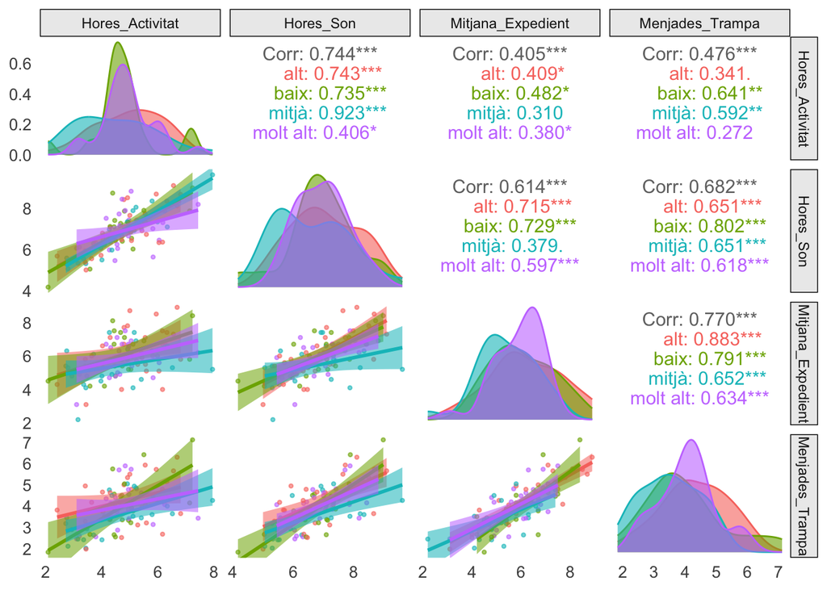

```r
quantitatives= dades %>% dplyr::select(1:4)
ggpairs(
  quantitatives,
  aes(color = dades$Nivell_Estres, fill = dades$Nivell_Estres, alpha = 0.6),
  lower = list(
    continuous = wrap("smooth", size = 0.8, alpha = 0.6),
    combo = wrap("box_no_facet", alpha = 0.7)
  ),
  upper = list(
    continuous = wrap("cor", size = 4)
  ),
  diag = list(
    continuous = wrap("densityDiag", alpha = 0.6)
  )
) +
  theme_minimal() +
  scale_color_manual(values = c("#F8766D", "#7CAE00", "#00BFC4", "#C77CFF")) +
  scale_fill_manual(values = c("#F8766D", "#7CAE00", "#00BFC4", "#C77CFF")) +
  theme(
    legend.position = "top",
    panel.grid = element_blank(),
    axis.text = element_text(size = 10),
    strip.background = element_rect(fill = "#ECECEC")
  )
```

Podem observar una clara relació lineal directe, és a dir, que quan una variable creix, les altres també ho fan. No obstant això, aquesta relació és més forta en altres. Per exemple, la mitjana de la nota, amb el nombre de menjades “trampa” té correlació 0,77, i podem observar al gràfic de dispersió, que els punts segueixen la tendència d’una recta. La que menys correlacionada està és la nota mitjana amb les hores d’activitat. Aquí la dependència és més feble, tot i que també es té que quan una variable creix, l’altre també, però menys marcat.

També ens sirà interessant pel nostre estudi comparar la mitjana de la nota de l’expedient amb les variables ordinals.

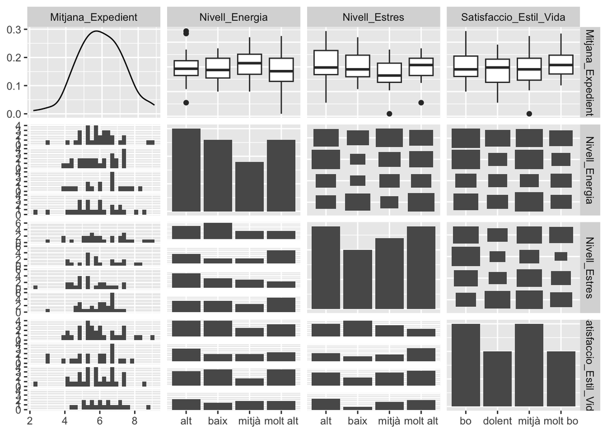

```r
ordinals= dades %>% dplyr::select(3,5:7)
ggpairs(ordinals)
```

```r
summary(aov(dades$Mitjana_Expedient~dades$Nivell_Estres))
```

```
                    Df Sum Sq Mean Sq F value Pr(>F)
dades$Nivell_Estres  3   9.29   3.098   2.031  0.115
Residuals           96 146.41   1.525
```

```r
summary(aov(dades$Mitjana_Expedient~dades$Nivell_Energia))
```

```
                     Df Sum Sq Mean Sq F value Pr(>F)
dades$Nivell_Energia  3   2.49   0.829   0.519   0.67
Residuals            96 153.21   1.596
```

```r
summary(aov(dades$Mitjana_Expedient~dades$Satisfaccio_Estil_Vida))
```

```
                             Df Sum Sq Mean Sq F value Pr(>F)
dades$Satisfaccio_Estil_Vida  3   3.97   1.325   0.838  0.476
Residuals                    96 151.73   1.581
```

Per acabar el nostre anàlisi descriptiu, vegem si afecta el tipus d’activitat física que feiem i la modalitat que estudiem.

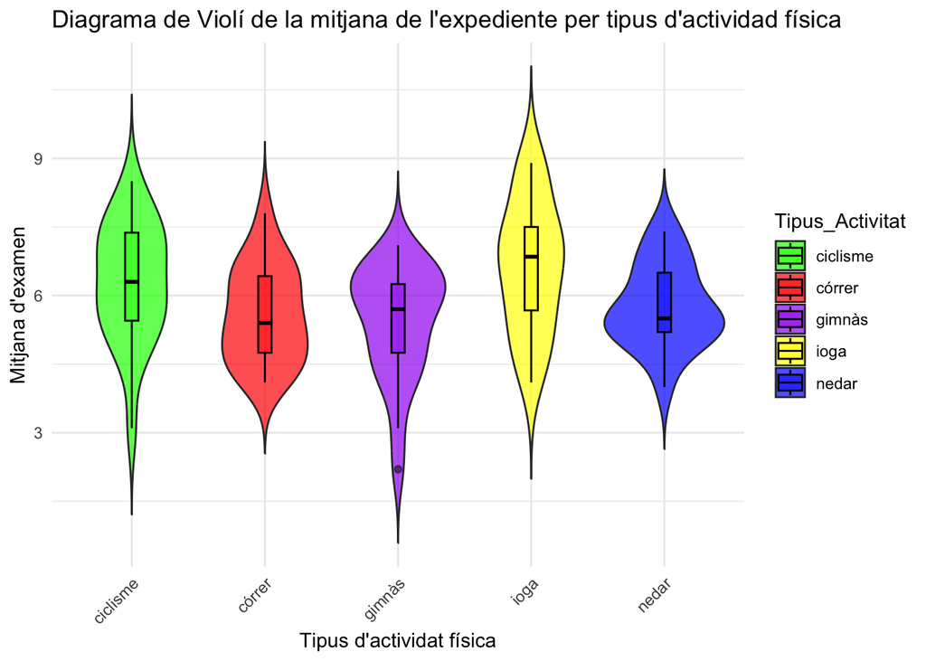

```r
ggplot(dades, aes(x = Tipus_Activitat, y = Mitjana_Expedient, fill = Tipus_Activitat)) +
  geom_violin(trim = FALSE, alpha = 0.7) +  # Diagrama de violí
  geom_boxplot(width = 0.1, color = "black", alpha = 0.5) +
  labs(title = "Diagrama de Violí de la mitjana de l'expediente per tipus d'actividad física",
       x = "Tipus d'actividat física", y = "Mitjana d'examen") +
  scale_fill_manual(values = c("córrer" = "red", "nedar" = "blue", "ciclisme" = "green",
                               "ioga" = "yellow", "gimnàs" = "purple")) +
  theme_minimal() +
  theme(axis.text.x = element_text(angle = 45, hjust = 1))
```

Amb aquest diagrama de violí, podem observar que hi ha gaire alguna diferència en com es distribueixen, podríem fer un altre test d’ANOVA i veure si les mitjanes són iguals o no.

```r
resultats_anova=aov(dades$Mitjana_Expedient~dades$Tipus_Activitat)
summary(resultats_anova)
```

```
                      Df Sum Sq Mean Sq F value Pr(>F)
dades$Tipus_Activitat  4  19.31   4.827   3.362 0.0128 *
Residuals             95 136.39   1.436
---
Signif. codes:  0 '***' 0.001 '**' 0.01 '*' 0.05 '.' 0.1 ' ' 1
```

Efectivament, tenim un $p$-valor baix (0.0128), i si considerem $\alpha=0.05$ i rebutgem la hipòtesi nul·la de que les mitjanes són totes igual, i tendríem diferències en les mitjanes. Executem el test de Tukey post-hoc per veure quines mitjanes difereixen entre elles.

```r
TukeyHSD(resultats_anova)
```

```
  Tukey multiple comparisons of means
    95% family-wise confidence level

Fit: aov(formula = dades$Mitjana_Expedient ~ dades$Tipus_Activitat)

$`dades$Tipus_Activitat`
                      diff        lwr       upr     p adj
córrer-ciclisme -0.7200000 -1.7494663 0.3094663 0.3011745
gimnàs-ciclisme -0.8782609 -1.8719369 0.1154152 0.1092336
ioga-ciclisme    0.3125000 -0.7822987 1.4072987 0.9318319
nedar-ciclisme  -0.5368421 -1.5804026 0.5067183 0.6096545
gimnàs-córrer   -0.1582609 -1.1770144 0.8604927 0.9926366
ioga-córrer      1.0325000 -0.0851095 2.1501095 0.0844470
nedar-córrer     0.1831579 -0.8843088 1.2506246 0.9892544
ioga-gimnàs      1.1907609  0.1060295 2.2754923 0.0239893
nedar-gimnàs     0.3414188 -0.6915751 1.3744127 0.8888754
nedar-ioga      -0.8493421 -1.9799475 0.2812633 0.2333645
```

Anem a fer el mateix amb els diferents tipus de modalitats d’estudi.

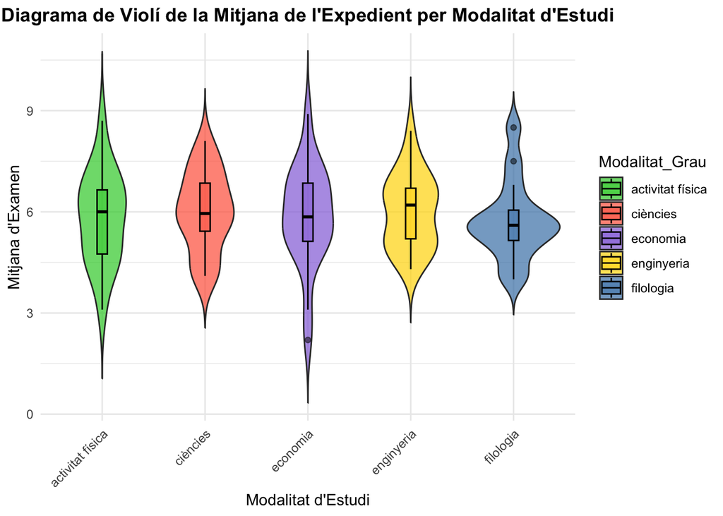

```r
library(ggplot2)

# Crear diagrama de violí per a les modalitats d'estudi
ggplot(dades, aes(x = Modalitat_Grau, y = Mitjana_Expedient, fill = Modalitat_Grau)) +
  geom_violin(trim = FALSE, alpha = 0.7) +  # Diagrama de violí
  geom_boxplot(width = 0.1, color = "black", alpha = 0.5) +  # Boxplot superposat
  labs(
    title = "Diagrama de Violí de la Mitjana de l'Expedient per Modalitat d'Estudi",
    x = "Modalitat d'Estudi",
    y = "Mitjana d'Examen"
  ) +
  scale_fill_manual(values = c("ciències" = "#FF6347", "filologia" = "#4682B4",
                               "activitat física" = "#32CD32", "enginyeria" = "#FFD700",
                               "economia" = "#9370DB")) +
  theme_minimal() +
  theme(
    axis.text.x = element_text(angle = 45, hjust = 1),
    plot.title = element_text(hjust = 0.5, face = "bold")
  )
```

Aquí sí que sembla que totes les mitjanes són iguales. Anem a fer el test ANOVA.

```r
resultats_anova_2=aov(dades$Mitjana_Expedient~dades$Modalitat_Grau)
summary(resultats_anova_2)
```

```
                     Df Sum Sq Mean Sq F value Pr(>F)
dades$Modalitat_Grau  4   1.04  0.2608    0.16  0.958
Residuals            95 154.66  1.6280
```

Efectivament, el $p$-valor és prou gran (0.958) per quedar-mos amb la hipòtesi nul·la de que totes les mitjanes són iguales.

Per acabar l’anàlisi descriptiu, ens pot resultar prou útil mirar la variància generalitzada i la variància total per veure com es dispersionen les dades.

```r
var_gen = quantitatives %>% as.matrix() %>% cov() %>% det()
var_tot = quantitatives %>% as.matrix() %>% cov() %>% diag() %>% sum()
var_gen
```

```
[1] 0.2527739
```

```r
var_tot
```

```
[1] 5.181528
```

Fixem-nos que la variància generalitzada és molt baixa (0.2527739), això ens indica que hi ha una baixa variabilitat entre les diferents variables estudiades. Notem que concorda amb la matriu de dispersió vista anteriorment, ja que els punts es reparteixen similarment en tots els casos. La variació total ens indica la variabilitat de les variables quantitatives a tot el conjunt de dades, és més alta (5.181528), això voldria dir que la diferència de la variabilitat total de les dades en conjunt és bastant més notable que no si les mirem en cada grup.

Un cop hem acabat amb l’anàlisi descriptiu, anem a **modelitzar** les diferents modalitats estudiades pels alumnes a partir d’una distribució binomial. Per això haurem d’estimars els paràmetres $p_{ciències}$, $p_{filologia}$, $p_{activitat física}$, $p_{enginyeria}$ i $p_{economia}$ . Aquesta aproximació dels paràmetres ho farem amb els estimadors de màxima versemblança, i.e., les freqïuències relatives. Anem a calcular-les:

```r
modalitat_freq <- dades %>%
  count(Modalitat_Grau) %>%
  mutate(proporcio = n / sum(n))

# Mostrar las proporciones calculadas
p=modalitat_freq %>% dplyr::select(proporcio)
p
```

```
  proporcio
1      0.19
2      0.22
3      0.22
4      0.22
5      0.15
```

```r
t(p)
```

```
          [,1] [,2] [,3] [,4] [,5]
proporcio 0.19 0.22 0.22 0.22 0.15
```

```r
cas <- c(4,1,8,4,3)
probab= dmultinom(cas,size = 20, t(p))
probab
```

```
[1] 0.0002171768
```

Per continuar estudiant aquesta mostra, ens pot resultar interessant poder estimar la mitjana d’expedient d’un alumne a partir de les hores d’activitat física que fa un alumne a la setmana, la mitjana d’hores de son al dia i el nombre de menjades “trampa” que fa un alumne per setmana. Això es tradueix en fer un model de regressió multilineal de l’estil:

$$Y=\beta_0+\beta_1X_1+\beta_2X_2+\beta_3X_3+\epsilon$$

On $Y$ és la variable de la mitjana de la nota de l’expedient i $X_i$ són les altres variables quantitatives.

```r
model <- lm(Mitjana_Expedient ~ Hores_Activitat + Hores_Son + Menjades_Trampa, data = dades)

# Resum del model ajustat
summary(model)
```

```
Call:
lm(formula = Mitjana_Expedient ~ Hores_Activitat + Hores_Son +
    Menjades_Trampa, data = dades)

Residuals:
     Min       1Q   Median       3Q      Max
-2.24895 -0.45012  0.07108  0.49742  1.73784

Coefficients:
                Estimate Std. Error t value Pr(>|t|)
(Intercept)      1.45211    0.52971   2.741   0.0073 **
Hores_Activitat -0.07834    0.10529  -0.744   0.4587
Hores_Son        0.25971    0.13425   1.935   0.0560 .
Menjades_Trampa  0.76076    0.10194   7.463 3.83e-11 ***
---
Signif. codes:  0 '***' 0.001 '**' 0.01 '*' 0.05 '.' 0.1 ' ' 1

Residual standard error: 0.7957 on 96 degrees of freedom
Multiple R-squared:  0.6097,    Adjusted R-squared:  0.5975
F-statistic: 49.98 on 3 and 96 DF,  p-value: < 2.2e-16
```

$$S(\beta) = \frac{1}{\sigma^2} X^T (Y - X\beta)$$

on:

```r
X=quantitatives %>% mutate(1) %>% dplyr::select(5,1,2,4) %>% as.matrix()
Y=quantitatives%>% dplyr::select(3)%>%as.matrix()
beta=model$coefficients
```

Si la funció de score és zero, això significa que el model ha assolit un màxim de versemblança respecte a $\beta$, i les estimacions actuals (és a dir, $\hat{\beta}$) són els valors que maximitzen la probabilitat d’observar les dades actuals.

```r
t(X)%*%(Y-X%*%beta)
```

```
                Mitjana_Expedient
1                    1.723066e-13
Hores_Activitat      8.434917e-13
Hores_Son            1.238614e-12
Menjades_Trampa      7.252249e-13
```

Notem que efectivament tenim $S(\beta)\approx 0$.

Ara podríem fer previsions amb aquest model. Per exemple, calcularem la predicció de la mitjana de l’expedient d’un alumne que fa 6 hores d’activitat física setmanals, que dorm una mitja de 7 hores i mitja i que fa 5 menjades trampa a la setmana:

```r
nou_estudiant <- data.frame(Hores_Activitat = 6, Hores_Son = 7.5, Menjades_Trampa = 5)
prediccio <- predict(model, newdata = nou_estudiant)
prediccio
```

```
       1
6.733716
```

L’alumne amb les anteriors característiques esmentades, predim que té una mitjana d’expedient de 6.733716.

Ara, per últim, farem un contrast d’hipòtesi i per veure que la gent que té d’activitat física actual, córrer, té les mateixes mitjanes que la gent que neda, amb una significació de $\alpha=0.05$. És a dir $H_0:\mu_{córrer}=\mu_{nedar}$ i $H_1:\mu_{córrer}\neq \mu_{nedar}$

```r
library(Hotelling)
dades_filtrades <- dades %>%
  filter(Tipus_Activitat %in% c("nedar", "córrer"))
grup_nedar <- dades_filtrades %>%
  filter(Tipus_Activitat == "nedar") %>%
  dplyr::select(Hores_Activitat, Hores_Son, Menjades_Trampa, Mitjana_Expedient)
grup_correr <- dades_filtrades %>%
  filter(Tipus_Activitat == "córrer") %>%
  dplyr::select(Hores_Activitat, Hores_Son, Menjades_Trampa, Mitjana_Expedient)
print(hotelling.test(grup_nedar, grup_correr))
```

```
Test stat:  11.397
Numerator df:  4
Denominator df:  34
P-value:  0.05209
```

Notem que el $p$-valor>0.05, llavors acceptem la hipòtesi nul·la, i ens quedem amb que les mitjanes són iguals.

Ara realitzarem el mateix contrast, però de manera teòrica. Calculant l’estadístic del test de Hotelling $T^2$ , i relacionant-lo amb la distribució de Fisher. Per això, hem de calcular la matriu de covariàncies combinada:

$$Sp = \frac{n_1S_1 + n_2 S_2 }{n_1 + n_2 - 2}$$

Llavors, tenim:

$$T^2=\frac{n_1n_2}{n_1+n_2}(\bar{x}-\bar{y})S_p^{-1}(\bar{x}-\bar{y})\sim T^2(p,n_1+n_2-2)$$

i que:

$$\frac{n_1+n_2-1-p}{(n_1+n_2-2)p}T^2\sim F^p_{n_1+n_2-1-p}$$

```r
p=4
S_1=grup_nedar %>% dplyr::select(1:4) %>% as.matrix() %>% cov()
S_2=grup_correr %>% dplyr::select(1:4) %>% as.matrix() %>% cov()
n_1=nrow(grup_correr)
n_2=nrow(grup_nedar)
bar_x=colMeans(grup_correr)
bar_y=colMeans(grup_nedar)
S_p=(n_1*S_1+n_2*S_2)/(n_1+n_2-2)
T_2=mahalanobis(bar_x,bar_y,(n_1+n_2)*S_p/(n_1*n_2))
T_2
```

```
[1] 10.68928
```

```r
est=((n_1+n_2-1-p)/((n_1+n_2-2)*p))*T_2
est
```

```
[1] 2.455646
```

```r
p_valor=pf(est,p,n_1+n_2-1-p)
p_valor
```

```
[1] 0.9356628
```

## Bibliografia

·Apuntes de la asignatura

·Apuntes estadística UIB